# 07_read_movement_data

### Reading and Analyzing Movement Detection Data

API M enabled clients now have the ability to detect movement onboard when one or both of the gyroscope and accelerometer sensors are enabled.

Movement data is stored in packets as part of an [EventStream](https://redvoxinc.github.io/redvox-sdk/v3.0.0a14/api_docs/redvox/api1000/wrapped_redvox_packet/event_streams.html).

The SDK provides methods for converting the EventStream into a more friendly MovementEventStream.

```python
from dataclasses import dataclass
import datetime
from functools import reduce
from typing import List, Optional, Tuple, TYPE_CHECKING

import matplotlib.pyplot as plt
import numpy as np

import redvox.api1000.io_raw as io
from redvox.api1000.wrapped_redvox_packet.sensors.derived.movement import MovementEventStream, MovementChannel
from redvox.common.date_time_utils import datetime_from_epoch_microseconds_utc

if TYPE_CHECKING:
    from redvox.api1000.wrapped_redvox_packet.event_streams import EventStream
    from redvox.api1000.wrapped_redvox_packet.sensors.sensors import Sensors
    from redvox.api1000.wrapped_redvox_packet.sensors.xyz import Xyz
    from redvox.api1000.wrapped_redvox_packet.wrapped_packet import WrappedRedvoxPacketM
```

### Encapsulating the Movement Data

Let's start by create a class to hold the movement data from multiple packets.

```python
@dataclass
class MovementData:
    """
    Encapsulates movement data from multiple packets.
    """
    gyroscope_ts: np.ndarray = np.array([])
    gyroscope_samples_x: np.ndarray = np.array([])
    gyroscope_samples_y: np.ndarray = np.array([])
    gyroscope_samples_z: np.ndarray = np.array([])
    accel_ts: np.ndarray = np.array([])
    accel_samples_x: np.ndarray = np.array([])
    accel_samples_y: np.ndarray = np.array([])
    accel_samples_z: np.ndarray = np.array([])
    movement_event_stream: MovementEventStream = MovementEventStream("Movement", [])
```

Next, let's write a function that given a list of packets from a single station, extract and concatenate the relevant movement data. This include any gyroscope timestamps and samples, accelerometer timestamps and samples, and the station derived movement events themselves.

You'll note that MovementEventStream.from_event_stream is used to convert from the generic 'EventStream' into an easier to use 'MovementEventStream'.

```python
def extract_movement_data(packets: List['WrappedRedvoxPacketM']) -> MovementData:
    """
    Extracts and concatenates movement data from a list of packets.
    :param packets: Packets to extract movement data from.
    :return: The encapsulated movement data.
    """

    def reduce_fn(acc: MovementData, packet: 'WrappedRedvoxPacketM') -> MovementData:
        """
        This function is passed to reduce and provides the role of accumulating movement data from packet and storing
        it in acc.
        :param acc: The accumulator.
        :param packet: The packet.
        :return: The updated movement data (the accumulator).
        """
        sensors: 'Sensors' = packet.get_sensors()

        # Extract gyroscope timestamps and X, Y, Z samples if gyroscope exists
        gyro: Optional[Xyz] = sensors.get_gyroscope()
        if gyro is not None:
            acc.gyroscope_ts = np.concatenate([acc.gyroscope_ts, gyro.get_timestamps().get_timestamps()])
            acc.gyroscope_samples_x = np.concatenate([acc.gyroscope_samples_x, gyro.get_x_samples().get_values()])
            acc.gyroscope_samples_y = np.concatenate([acc.gyroscope_samples_y, gyro.get_y_samples().get_values()])
            acc.gyroscope_samples_z = np.concatenate([acc.gyroscope_samples_z, gyro.get_z_samples().get_values()])

        # Extract accelerometer timestamps and X, Y, Z samples if accelerometer exists
        accel: Optional[Xyz] = sensors.get_accelerometer()
        if accel is not None:
            acc.accel_ts = np.concatenate([acc.accel_ts, accel.get_timestamps().get_timestamps()])
            acc.accel_samples_x = np.concatenate([acc.accel_samples_x, accel.get_x_samples().get_values()])
            acc.accel_samples_y = np.concatenate([acc.accel_samples_y, accel.get_y_samples().get_values()])
            acc.accel_samples_z = np.concatenate([acc.accel_samples_z, accel.get_z_samples().get_values()])

        # Extract the derived EventStreams and convert them into MovementEventStreams.
        event_streams: List['EventStream'] = packet.get_event_streams().get_values()
        if len(event_streams) == 1:
            movement_event_stream: MovementEventStream = MovementEventStream.from_event_stream(event_streams[0])
            acc.movement_event_stream.movement_events.extend(movement_event_stream.movement_events)

        return acc

    return reduce(reduce_fn, packets, MovementData())
```

### Loading the movement data

Next, we'll go ahead load the data packets and extract the movement data.

```python
# Read in the data
read_res: io.ReadResult = io.read_unstructured("/home/jupyter-isla/api1000_example/data/movement")

# Extract packets for the station that contained movement data
packets: List['WrappedRedvoxPacketM'] = read_res.get_packets_for_station_id("2553")

# Extract, concat, and encapsulate movement data as described above
movement_data: MovementData = extract_movement_data(packets)
```

### Examining the MovementEventStream

Before we make any plots, we can actually go through each movement event and see what was captured by the station. Let's print out the first 5 detected movements as examples.

You'll note that each derived event contains:

- The sensor and channel that captured the movement
- The start and end of the movement as microseconds since the epoch UTC
- The duration of the movement in microseconds
- The min, max, range, mean, and standard deviation of the square of the movement magnitude

```python
for movement_event in movement_data.movement_event_stream.movement_events[:5]:
    print(movement_event)
```

```
MovementEvent(movement_channel=<MovementChannel.ACCELEROMETER_X: 'ACCELEROMETER_X'>, movement_start=1602030129020417.0, movement_end=1602030132173852.0, movement_duration=3153435.0, magnitude_min=3.57850012775268e-07, magnitude_max=30.308181578431913, magnitude_range=30.3081812205819, magnitude_mean…
MovementEvent(movement_channel=<MovementChannel.ACCELEROMETER_Y: 'ACCELEROMETER_Y'>, movement_start=1602030129020417.0, movement_end=1602030131960677.0, movement_duration=2940260.0, magnitude_min=8.946250667583226e-06, magnitude_max=38.215357316957125, magnitude_range=38.21534837070646, magnitude_me…
MovementEvent(movement_channel=<MovementChannel.ACCELEROMETER_Z: 'ACCELEROMETER_Z'>, movement_start=1602030129275593.0, movement_end=1602030131769370.0, movement_duration=2493777.0, magnitude_min=0.0007572106206255591, magnitude_max=1176.5663618652761, magnitude_range=1176.5656046546555, magnitude_m…
MovementEvent(movement_channel=<MovementChannel.GYROSCOPE_X: 'GYROSCOPE_X'>, movement_start=1602030129484644.0, movement_end=1602030131413747.0, movement_duration=1929103.0, magnitude_min=1.700093346419123e-05, magnitude_max=10.63616534358971, magnitude_range=10.636148342656245, magnitude_mean=2.825…
MovementEvent(movement_channel=<MovementChannel.GYROSCOPE_Y: 'GYROSCOPE_Y'>, movement_start=1602030129586077.0, movement_end=1602030131521862.0, movement_duration=1935785.0, magnitude_min=2.3320898359682855e-08, magnitude_max=7.597164566793765, magnitude_range=7.597164543472867, magnitude_mean=1.005…
```

### Plotting Movement Data

Now that we have an understanding of what the derived movement metadata looks like, let's use this information to visualize movements alongside the actual gyroscope and accelerometer data. Let's make a figure that plots the power of the signal as well as derived movements that span the signal and represent the mean movement magnitude.

Representing movement on the plot is a little tricky at first glance. We have the start and end time of the movement, and do not want non-movement to be shown at all. To achieve this, we'll use a little trick that matplotlib does not connect series that have NaNs in-between.

Let's write a function that takes a MovementEventStream and converts it into a matplotlib friendly series of datetimes for the x-axis and a numpy array for the y-axis. We will use the movement's mean magnitude as y-values.

```python
def extract_movement_series(movement_event_stream: MovementEventStream,
                            channel: MovementChannel) -> Tuple[List[datetime.datetime], np.ndarray]:
    """
    Given an MovementEventStream and a specified channel, transform the movement data into a list of datetimes and a
    numpy array representing the mean magnitude of the movement. This function inserts NaNs in-between movement so that
    the series is broken up when displayed by matplotlib.
    :param movement_event_stream: A movement event stream to extract series information from.
    :param channel: Channel to extract movement data from.
    :return: A tuple of (datetimes, y-values)
    """
    dts: List[datetime.datetime] = []
    samples: List[float] = []

    for movement_event in movement_event_stream.events_by_channel(channel):
        dts.extend([
            movement_event.movement_start_dt(),
            movement_event.movement_end_dt(),
            # Insert a timestamp directly after the movement end to associate with a nan
            movement_event.movement_end_dt() + datetime.timedelta(seconds=.0001)
        ])
        samples.extend([
            movement_event.magnitude_mean,
            movement_event.magnitude_mean,
            # Insert a nan to break up series in the plot
            float("nan")
        ])

    return dts, np.array(samples)

def plot_movement(movement_data: MovementData, station_id: str) -> None:
    """
    Plot the square of the sensor channels against the mean magnitude of detected movement.
    :param movement_data: Encapsulated movement data.
    :param station_id: Station that is being plotted.
    """

    # Setup the plot
    fig: plt.Figure
    axes: List[plt.Axes]
    fig, axes = plt.subplots(3, 2, figsize=(16, 9))
    fig.subplots_adjust(hspace=0.5)

    gyro_x_ax: plt.Axes = axes[0][0]
    gyro_y_ax: plt.Axes = axes[1][0]
    gyro_z_ax: plt.Axes = axes[2][0]

    accel_x_ax: plt.Axes = axes[0][1]
    accel_y_ax: plt.Axes = axes[1][1]
    accel_z_ax: plt.Axes = axes[2][1]

    # Convert timestamps to datetimes for gyro and accel samples
    gyro_dts: List[datetime.datetime] = list(map(datetime_from_epoch_microseconds_utc, movement_data.gyroscope_ts))
    accel_dts: List[datetime.datetime] = list(map(datetime_from_epoch_microseconds_utc, movement_data.accel_ts))

    # Convert the movement data into something matplotlib can work with
    (gyro_x_movement_dts, gyro_x_movement_samples) = extract_movement_series(movement_data.movement_event_stream,
                                                                             MovementChannel.GYROSCOPE_X)
    (gyro_y_movement_dts, gyro_y_movement_samples) = extract_movement_series(movement_data.movement_event_stream,
                                                                             MovementChannel.GYROSCOPE_Y)
    (gyro_z_movement_dts, gyro_z_movement_samples) = extract_movement_series(movement_data.movement_event_stream,
                                                                             MovementChannel.GYROSCOPE_Z)

    (accel_x_movement_dts, accel_x_movement_samples) = extract_movement_series(movement_data.movement_event_stream,
                                                                               MovementChannel.ACCELEROMETER_X)
    (accel_y_movement_dts, accel_y_movement_samples) = extract_movement_series(movement_data.movement_event_stream,
                                                                               MovementChannel.ACCELEROMETER_Y)
    (accel_z_movement_dts, accel_z_movement_samples) = extract_movement_series(movement_data.movement_event_stream,
                                                                               MovementChannel.ACCELEROMETER_Z)

    gyro_x_ax.plot(gyro_dts, movement_data.gyroscope_samples_x * movement_data.gyroscope_samples_x, label="Samples")
    gyro_x_ax.plot(gyro_x_movement_dts,
                   gyro_x_movement_samples,
                   color="red",
                   label="Detected Movement (mean magnitude)")
    gyro_x_ax.set_title("Gyroscope X")
    gyro_x_ax.set_ylabel("$(rad/s)^2$")
    gyro_x_ax.set_xlabel("Date/Time (UTC)")
    gyro_x_ax.legend()

    gyro_y_ax.plot(gyro_dts, movement_data.gyroscope_samples_y * movement_data.gyroscope_samples_y, label="Samples")
    gyro_y_ax.plot(gyro_y_movement_dts,
                   gyro_y_movement_samples,
                   color="red",
                   label="Detected Movement (mean magnitude)")
    gyro_y_ax.set_title("Gyroscope Y")
    gyro_y_ax.set_ylabel("$(rad/s)^2$")
    gyro_y_ax.set_xlabel("Date/Time (UTC)")
    gyro_y_ax.legend()

    gyro_z_ax.plot(gyro_dts, movement_data.gyroscope_samples_z * movement_data.gyroscope_samples_z, label="Samples")
    gyro_z_ax.plot(gyro_z_movement_dts,
                   gyro_z_movement_samples,
                   color="red",
                   label="Detected Movement (mean magnitude)")
    gyro_z_ax.set_title("Gyroscope Z")
    gyro_z_ax.set_ylabel("$(rad/s)^2$")
    gyro_z_ax.set_xlabel("Date/Time (UTC)")
    gyro_z_ax.legend()

    accel_x_ax.plot(accel_dts, movement_data.accel_samples_x * movement_data.accel_samples_x, label="Samples")
    accel_x_ax.plot(accel_x_movement_dts,
                    accel_x_movement_samples,
                    color="red",
                    label="Detected Movement (mean magnitude)")
    accel_x_ax.set_title("Accelerometer X")
    accel_x_ax.set_ylabel("$(m/s^2)^2$")
    accel_x_ax.set_xlabel("Date/Time (UTC)")
    accel_x_ax.legend()

    accel_y_ax.plot(accel_dts, movement_data.accel_samples_y * movement_data.accel_samples_y, label="Samples")
    accel_y_ax.plot(accel_y_movement_dts,
                    accel_y_movement_samples,
                    color="red",
                    label="Detected Movement (mean magnitude)")
    accel_y_ax.set_title("Accelerometer Y")
    accel_y_ax.set_ylabel("$(m/s^2)^2$")
    accel_y_ax.set_xlabel("Date/Time (UTC)")
    accel_y_ax.legend()

    accel_z_ax.plot(accel_dts, movement_data.accel_samples_z * movement_data.accel_samples_z, label="Samples")
    accel_z_ax.plot(accel_z_movement_dts,
                    accel_z_movement_samples,
                    color="red",
                    label="Detected Movement (mean magnitude)")
    accel_z_ax.set_title("Accelerometer Z")
    accel_z_ax.set_ylabel("$(m/s^2)^2$")
    accel_z_ax.set_xlabel("Date/Time (UTC)")
    accel_z_ax.legend()

    fig.suptitle(f"Detected Movement for {station_id} @ "
                 f"{movement_data.movement_event_stream.movement_events[0].movement_start_dt()}")

    fig.show()
```

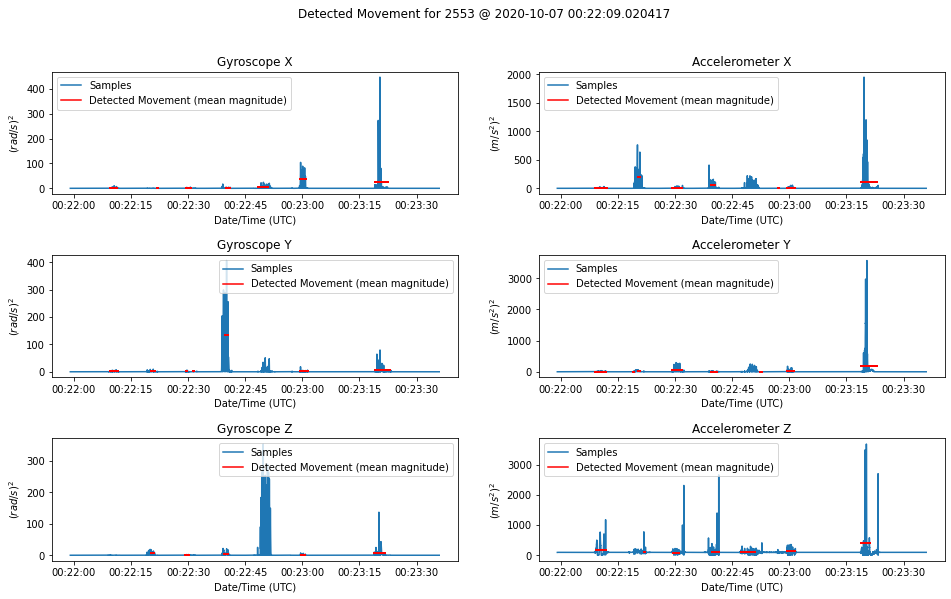

```python
plot_movement(movement_data, "2553")
```